# Midterm

Kaiwen Yang

# Motivation & Reearch Quesiton

###### It’s been always discussed that living in a good neighbourhood will help you to reduce the risk of getting involved in a crime such as robbery, break and enter, homicides. Our parents and teachers had always told us not to go to the street in the neighbourhood with a bad reputation which occurred lots of major crimes such as robbery, theft and shooting. Those discussions about crimes really frightens me. While living in downtown Toronto, which is supposed to be a place where people have a relatively higher income compared to those cities and towns nearby, there are frequent robberies happening, even in front of the Robarts Library, while there are really few robberies reported in the nearby cities. Therefore, I’m really questioning the experiences I’ve learned from my parents and teachers. This inspired me about whether living in a high-quality neighbourhood would really reduce the possibility or frequency of crimes happening. Considering that people with high income would rather pay more on the normal goods such as rents and houses with rigorous security, while homeless people are not capable of securing their safety and properties, I decided to conduct an analysis on it.

###### The research seeks to investigate whether there exists a correlation between the individual income level of a neighborhood and the frequency of crime, particularly focusing on robbery incidents. Specifically, the hypothesis is whether higher-income neighborhoods experience lower rates of robbery compared to lower-income neighborhoods.

# Dataset

###### The first data I use is the Census of Toronto City’s 158 neighbourhoods of the year 2021 from the Toronto Open Data Catalogue. It is part of the census of Population in Canada, which collects data every five years on demographics, social, and economic aspects. It includes information such as neighbourhood name, average and median income of each neighborhood in Toronto. The data is sourced from Statistics Canada which covers Census years 2001, 2006, 2011, 2016, and 2021.

###### The second dataset I use is a group of 7 crime datasets from the Toronto Police Service Public Safety Data Portal, including recorded roberry, break and enter, homicides, shooting and different types of theft during the time between 1995 to 2023, where most of the recorded data are between 2015 to 2023. Since all of the dataset are recorded by the same department, the columns are similar, which stores the unique crime id, occurrence and recorded date, year, month, day of the week, hour, division type, location type, premises type, type of offense, type of crime, neighbourhood, status, longitude and latitude.

# Methods

###### To begin with, I read in the 7 crime datasets downloaded from the Toronto Police Department Open Dataset Catalogue. Since the datasets were created by the same organization, the columns are similar such that I stacked them together to form a full dataset containing different types of crime, and the size of it is 217425 rows with 44 columns. First, I created an indicator variable “Robbery” to indicate whether the crime is robbery since our main focus is on Robbery. Second, I created a new variable “OCC_Month_Numeric” by transforming the occurrence month stored as a string to corresponding numerical number which could be stored for later use since it is easier to operate on numerical parameters. Then, I created a new variable “Occurence_Time” which stores the exact year, month, day of the month and the hour of the crime. In addition, I created a new variable “Day_Of_Week_Numeric” by converting the day of the week stored as a string to numeric representation, which has the similar purpose as occurrence month. Considering the size of the dataset and the complex column names, I decided to subset the data with necessary columns include: “Crime_Category”,“Robbery”, “Occurrence_Time”, “Year”, “Month”, “Day_Of_Week_Numeric”, “Hour”, “Neighbourhood”, “Location_Type”, “Premises_Type”, “Longitude”, “Latitude”. I also created a new indicator variable “Darkness”, which indicates whether the sky is dark when the crime occurred, and it is determined by whether the hour of the day is after the sunset and before the sunrise. I determined the time of sunset and sunrise is 18 and 6 respectively, by common sense, and I would like to discover that further if time allows. By common senseI realized that the sunset and sunrise time differs by seasons, and the crime frequency might change with holidays and temperature. After doing literature review, I created a new variable “Season” by grouping the months. Finally, since the second data I’m going to use is restricted in the year of 2020, and since I may utilize census data in another year, I subset the dataset to a smaller dataset storing only crimes in 2020 instead of directly changing the full dataset. The filtered dataset comes to a size of 19153 rows with 14 columns.

###### Additionally, I read in the transposed 2021 census dataset downloaded from the Toronto Open Data Catalogue, It is transposed since it is not formatted as I want, which is storing Neighbourhood Names as a column, not as the original datasets stores each neighbourhood name as each column. Since I’m interested in the income of individuals living in each neighbourhood, I select columns storing the median and average total income in 2020 due to efficiency. I also keep the column of “Neighbourhood Name” for the purpose of future possible merge with the crime dataset. Then, I checked for differences in the stored neighbourhood value for each dataset using set difference, and found there are 7 neighbourhood values stored expressively differently. A classical example would be storing “Taylor Massey” instead of “Taylor-Massey”. I then updated all values in the census dataset.

# Tabular Tables

###### To start with, I summarized statistics in tabular form. For the crime dataset of 2020, there are 72 missing values in “Day_Of_Week_Numeric”, 71 missing values in “Hour”. For the income dataset of 2020, the minimum, first quantile, median, mean, third quartile and max of “Average_Income” is 33720, 43190, 55375, 64037, 71300 and 237600, respectively, and for “Median_Income” is 28400, 34000, 39000, 41985, 46400 and 74500, respectively.

Numerical variables in Crime Data of 2020

|  | Day_Of_Week_Numeric | Hour |
| --- | --- | --- |
|  | Min. :1.000 | Min. : 0.00 |
|  | 1st Qu.:2.000 | 1st Qu.: 5.00 |
|  | Median :4.000 | Median :14.00 |
|  | Mean :4.054 | Mean :12.49 |
|  | 3rd Qu.:6.000 | 3rd Qu.:19.00 |
|  | Max. :7.000 | Max. :23.00 |
|  | NA’s :72 | NA’s :71 |

Numerical variables in Income Data of 2020

|  | Average_Income | Median_Income |
| --- | --- | --- |
|  | Min. : 33720 | Min. :28400 |
|  | 1st Qu.: 43190 | 1st Qu.:34000 |
|  | Median : 55375 | Median :39000 |
|  | Mean : 64037 | Mean :41985 |
|  | 3rd Qu.: 71300 | 3rd Qu.:46400 |
|  | Max. :237600 | Max. :74500 |

Categorical variables in Crime Data of 2020

| Crime_Category | Season | Darkness | Freq |
| --- | --- | --- | --- |
| Auto Theft | Fall | 0 | 526 |
| Break and Enter | Fall | 0 | 613 |
| Robbery | Fall | 0 | 255 |
| Theft Over | Fall | 0 | 179 |
| Auto Theft | Spring | 0 | 518 |
| Break and Enter | Spring | 0 | 689 |
| Robbery | Spring | 0 | 313 |
| Theft Over | Spring | 0 | 132 |
| Auto Theft | Summer | 0 | 467 |
| Break and Enter | Summer | 0 | 570 |
| Robbery | Summer | 0 | 185 |
| Theft Over | Summer | 0 | 179 |
| Auto Theft | Winter | 0 | 475 |
| Break and Enter | Winter | 0 | 768 |
| Robbery | Winter | 0 | 348 |
| Theft Over | Winter | 0 | 166 |
| Auto Theft | Fall | 1 | 1139 |
| Break and Enter | Fall | 1 | 938 |
| Robbery | Fall | 1 | 378 |
| Theft Over | Fall | 1 | 143 |
| Auto Theft | Spring | 1 | 862 |
| Break and Enter | Spring | 1 | 1112 |
| Robbery | Spring | 1 | 397 |
| Theft Over | Spring | 1 | 107 |
| Auto Theft | Summer | 1 | 979 |
| Break and Enter | Summer | 1 | 1082 |
| Robbery | Summer | 1 | 379 |
| Theft Over | Summer | 1 | 148 |
| Auto Theft | Winter | 1 | 774 |
| Break and Enter | Winter | 1 | 1124 |
| Robbery | Winter | 1 | 524 |
| Theft Over | Winter | 1 | 143 |

# Figures

###### First, I plotted the top 5 and lowest 5 crime counts neighbourhoods, showing that there are acutually big differences in crime frequency between neighbourhoods.

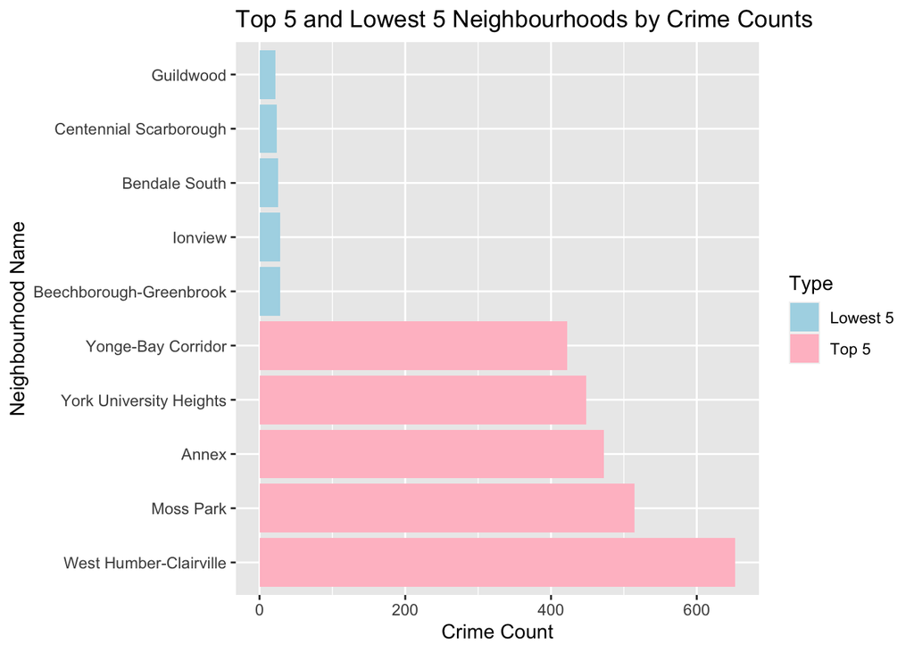

###### Additionally, I plotted the top 5 and lowest 5 crime counts neighbourhoods, showing that there are actually big differences in crime frequency between neighbourhoods. Afterwards, I plotted the top 5 and lowest 5 average income neighbourhoods, while finding that there are no matches or pairing with any of the top 5 and lowest 5 crime counts neighbourhoods.

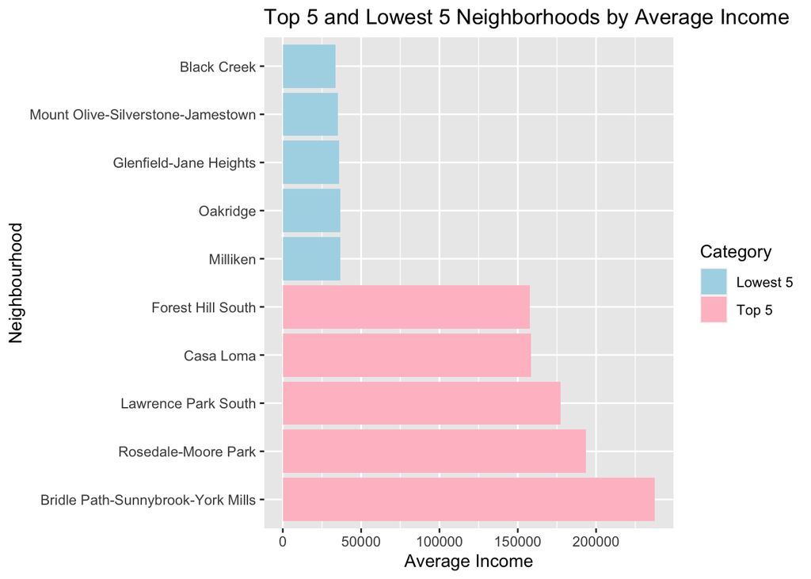

###### Considering that people with really high or low income may affect the average, I plotted the top 5 and lowest 5 median income neighbourhoods. It’s surprising that I still could not find any neighbours that match the top 5 and lowest 5 crime counts neighbourhoods.

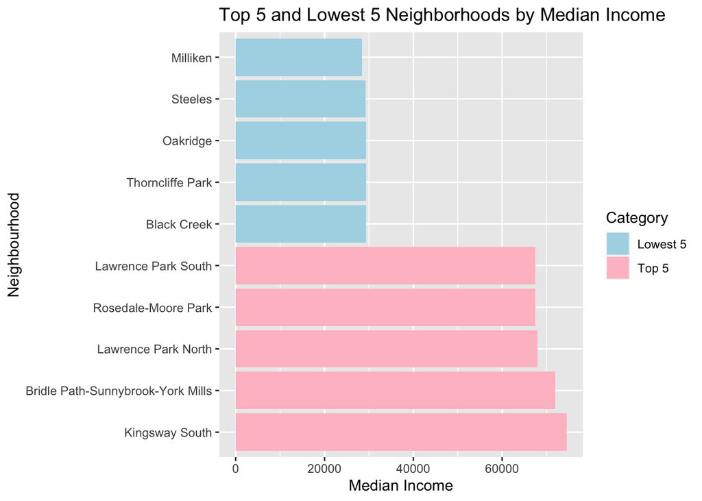

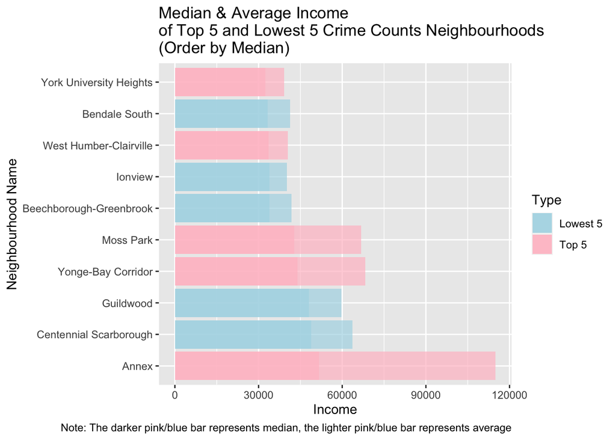

###### Finally, since there are still more information needed but not restricted to to confounders to answer my question, I simply tried using linear Regression to Classify whether a robbery crime could be identified among different types of crimes using “Robbery” as response variable, “Median_Income”, “Darkness” and “Season” as predictor. The estimate of “Median_Income” is -9.893e-06, which means that median income of a city has a really small impact on the likelihood of a robbery crime, which seems contrary to my expectation, but reasonable since it is not grouped by neighbourhoods.

# Summary:

###### Moreover, with Toronto boasting 158 different neighborhoods, interpreting the coefficients of models fitted with neighborhoods becomes considerably complex. Therefore, I plan to further delve into this matter to gain deeper insights.